# Week 10: Interaction terms in linear regression

Tristan Muno

November 25, 2026

## Week 10 goals

By the end of today, you will be able to:

1. Explain what an **interaction term** does: the slope of one predictor depends on another, the **moderator**.
2. Say how R turns a **categorical variable** into dummy variables around a **reference category**.
3. Write down and fit an **interaction model**, and read the slope of a predictor at each value of its moderator.
4. Compare several models in one **regression table** and with `loo_compare()`.
5. Show a conditional effect in a **figure**: expected and predicted values, and a **marginal-effects plot**.

## Today

1. **Recap:** reading a `brms` summary
2. **Interactions** in the linear predictor
3. **Categories** become dummy variables
4. **Our question and the eight steps**: a DAG, one interaction model and three to compare it with
5. **Reporting:** a table of four models, expected and predicted values, a marginal-effects plot

**Note**

**Last week, every predictor had one slope for everyone.** Today the slope of one predictor may change with the value of another.

## Where today fits

Last week: several predictors, each with **one** slope. Today: a slope that **depends** on another predictor, so steps 3 and 7 change most.

Table 1: The 8-step Bayesian workflow. Every homework exercises the steps introduced so far, cumulatively, and the exam runs all eight end to end.

| # | Step | What you produce |
| --- | --- | --- |
| 1 | **Estimand** | The quantity you want to learn about, stated precisely as a target before any model is fitted. |
| 2 | **Data summary** | The data described: measurement, coverage, obvious issues. |
| 3 | **Formal model** | Likelihood and priors written down, the generative model. |
| 4 | **Prior predictive check** | Simulate from the priors, confirm they imply plausible data. |
| 5 | **Fit** | Estimate with `brms`, weakly-informative priors by default. |
| 6a | **MCMC diagnostics** | R-hat, ESS, divergences, trace plots. Did sampling work? |
| 6b | **Posterior predictive check** | Does the fitted model reproduce key features of the data? |
| 7 | **Interpretation** | Answer the estimand on the outcome scale, with uncertainty. |
| 8 | **Limitations** | What the analysis can and cannot support, threats and next steps. |

# Recap

## Reading a `brms` summary

```r
summary(fit_week09)
```

```
 Family: gaussian
  Links: mu = identity
Formula: income ~ 0 + Intercept + edu12 + woman
   Data: income (Number of observations: 200)
  Draws: 4 chains, each with iter = 2000; warmup = 1000; thin = 1;
         total post-warmup draws = 4000

Regression Coefficients:
          Estimate Est.Error l-95% CI u-95% CI Rhat Bulk_ESS Tail_ESS
Intercept    37.60      0.44    36.76    38.44 1.00     2982     2408
edu12         1.57      0.24     1.11     2.04 1.00     2388     2337
woman       -18.49      1.20   -20.89   -16.13 1.00     2148     2064

Further Distributional Parameters:
      Estimate Est.Error l-95% CI u-95% CI Rhat Bulk_ESS Tail_ESS
sigma     4.54      0.23     4.11     5.03 1.00     2305     2219

Draws were sampled using sample(hmc). For each parameter, Bulk_ESS
and Tail_ESS are effective sample size measures, and Rhat is the potential
scale reduction factor on split chains (at convergence, Rhat = 1).
```

> **Q:** Where is the schooling slope, what is its 95 percent credible interval, and did the chains converge?

## What each block tells us

Table 2: The blocks of a `brms` summary, what each says and the workflow step that uses it.

| Block | What it says | Step |
| --- | --- | --- |
| `Formula`, `Data`, `Draws` | The model we wrote down, how many observations, how many posterior draws | 3, 5 |
| `Regression Coefficients` | One row per coefficient: posterior mean, posterior SD, 95 percent credible interval | 7 |
| `Further Distributional Parameters` | $\sigma$, the residual standard deviation | 7 |
| `Rhat`, `Bulk_ESS`, `Tail_ESS` | Did the chains converge, and how many effectively independent draws | 6a |

There is **one** schooling slope, so the model says schooling pays off **equally** for women and men. That was an assumption, not a finding.

> **Q:** How would we let the data tell us whether the slope differs?

# Interactions

## A product term in the linear predictor

Sometimes the association between a predictor $x$ and the outcome $y$ is **not constant**: it changes with a third variable $z$, the **moderator**. Last week, each predictor got its own term. To let $z$ change the slope of $x$, we add their **product**, an **interaction**:

$$\mu_i = \alpha + \beta_1 x_i + \beta_2 z_i + \beta_3 \, x_i z_i
\tag{1}$$

Collect the terms that multiply $x_i$:

$$\mu_i = (\alpha + \beta_2 z_i) + (\beta_1 + \beta_3 z_i) \, x_i
\tag{2}$$

- The **slope of $x$** is $\beta_1 + \beta_3 z_i$: it depends on $z$.
- $\beta_1$ is the slope of $x$ **where $z = 0$**, and only there.
- $\beta_3$ is how much the slope of $x$ changes **per unit of $z$**.

## A binary moderator: two lines

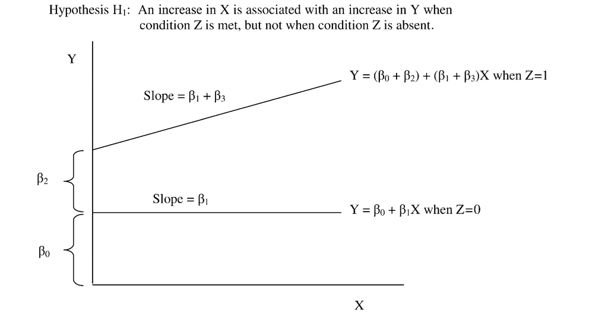

Figure 1: A binary moderator $z$ in Equation 1. Where $z = 0$ the line has slope $\beta_1$. Where $z = 1$ it starts $\beta_2$ higher and has slope $\beta_1 + \beta_3$. The authors write $\beta_0$ for our intercept $\alpha$. Source: Brambor et al. (2006).

## A continuous moderator: many lines

When $z$ is continuous, Equation 2 gives **one line for every value of $z$**, and the slope $\beta_1 + \beta_3 z$ changes smoothly.

**View source**

```r
expand_grid(x = c(-2, 2), z = c(-1, 0, 1)) |>
  mutate(
    mu = fan_beta_1 * x + fan_beta_3 * x * z,
    z_label = fct_inorder(
      case_match(z, -1 ~ "z = -1", 0 ~ "z = 0", 1 ~ "z = 1")
    )
  ) |>
  ggplot(aes(x = x, y = mu, colour = z_label)) +
  geom_line(linewidth = 1.2) +
  scale_colour_manual(values = c(col_1, col_4, col_2)) +
  theme_classic() +
  labs(
    x = "x",
    y = "Expected outcome",
    colour = NULL,
    title = "One slope for every value of z"
  )
```

[figure not shown]

Figure 2: Expected outcome against x at three values of a continuous moderator z, with illustrative values beta 1 = 0.5 and beta 3 = 0.8. The slope of x is 0.5 - 0.8 = -0.3 at z = -1, 0.5 at z = 0 and 1.3 at z = 1. A fan instead of parallel lines is what an interaction looks like.

## Categories become dummy variables

A model multiplies numbers, so R turns a categorical variable into **dummy variables** (1 or 0) before it fits. Take social class with three categories:

```r
people
```

```
# A tibble: 5 × 2
  person class
  <chr>  <fct>
1 Ana    working
2 Ben    middle
3 Cem    upper
4 Dana   working
5 Eli    middle
```

```r
model.matrix(~ class, data = people) |>
  as_tibble()
```

```
# A tibble: 5 × 3
  `(Intercept)` classmiddle classupper
          <dbl>       <dbl>      <dbl>
1             1           0          0
2             1           1          0
3             1           0          1
4             1           0          0
5             1           1          0
```

- $k$ categories become **$k - 1$ dummies**, here two.
- The category without a dummy is the **reference category**: by default the first level, here working class.
- Each dummy’s coefficient is a **difference from the reference**.

**Tip**

**The reference category is your choice.** Set it on purpose with `fct_relevel()`, so the comparisons answer your question.

# The eight steps

## Does who sits in parliament matter more in parliamentary systems?

> **Does the association between women in parliament and health spending depend on regime type?**

**Legislative composition theory**: in parliamentary systems the legislature controls the budget, so who sits in parliament should translate into spending more directly than in presidential systems, where power is divided between branches.

In the language of the last section:

- $y$: health spending, in percent of GDP
- $x$: women in parliament, in percent of seats
- $z$: regime type, the **moderator**
- $c$: GDP per capita, a **control**, in thousand USD

**Note**

**Our data: 120 countries, synthetic.** Regime type comes twice: a dummy (parliamentary or presidential) and a continuous index of legislative power from 0 to 1.

## Our theory as a DAG

**View source**

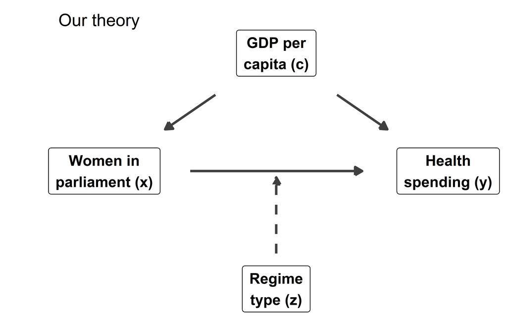

Figure 3: Our theory as a DAG. GDP per capita influences both women in parliament and health spending. Regime type, the dashed arrow, changes how strongly women in parliament is associated with health spending: it moderates that arrow.

```r
draw_dag(
  nodes = tibble(
    name = c("C", "X", "Y", "Z"),
    x = c(1.5, 0, 3, 1.5),
    y = c(1.5, 0, 0, -1.5),
    label = c("GDP per\ncapita (c)", "Women in\nparliament (x)", "Health\nspending (y)", "Regime\ntype (z)")
  ),
  edges = tibble(from = c("C", "C", "X"), to = c("X", "Y", "Y")),
  title = "Our theory",
  shrink = 0.75
) +
  annotate(
    "segment",
    x = 1.5,
    xend = 1.5,
    y = -1.05,
    yend = -0.08,
    arrow = arrow(length = unit(0.22, "cm"), type = "closed"),
    linewidth = 0.9,
    linetype = "dashed",
    colour = "grey25"
  ) +
  theme(plot.margin = margin(5, 10, 5, 45))
```

- **GDP is a fork**, a confounder: richer countries elect more women **and** spend more on health.
- Leaving it out credits its influence to women in parliament, so GDP is a **control**.
- Regime type points at the **arrow** from women in parliament to health spending: it is the moderator $z$.

**Note**

**The dashed arrow is a common shorthand, not part of a DAG’s rules.** A DAG only says whether variables are related, so strictly it cannot show that $z$ changes the strength of an arrow. In the model, the dashed arrow becomes the product term $x_i z_i$ at step 3, alongside $z_i$ itself.

## Step 1: Estimand

The research question:

> Is the association between women in parliament and health spending stronger in parliamentary systems?

What precisely do we want to learn?

> How much higher is expected health spending in a country with one more percentage point of women in parliament, **separately for presidential and parliamentary systems**, among countries with the same GDP?

Two **conditional** partial associations, and their **difference**. GDP is held constant because it is the fork in Figure 3.

**Warning**

**A conditional association is still not a causal effect.** Countries where women hold more seats may differ in other ways that also drive spending.

## Step 2: The data

```r
health |>
  group_by(regime) |>
  summarise(
    n = n(),
    women = mean(women_parl),
    power = mean(leg_power),
    gdp = mean(gdp_pc),
    spend = mean(health_spend)
  ) |>
  knitr::kable(
    digits = 1,
    col.names = c("Regime", "Countries", "Women (%)", "Legislative power", "GDP per capita", "Health spending (%)")
  )
```

Table 3: Number of countries and mean values by regime type. Legislative power is an index from 0 (weakest) to 1 (strongest legislature). Health spending is in percent of GDP, GDP per capita in thousand USD.

| Regime | Countries | Women (%) | Legislative power | GDP per capita | Health spending (%) |
| --- | --- | --- | --- | --- | --- |
| Presidential | 64 | 30.5 | 0.2 | 17.0 | 7.3 |
| Parliamentary | 56 | 32.1 | 0.8 | 17.6 | 9.1 |

> **Q:** Parliamentary systems spend more on average. Does that tell us whether spending rises more steeply with women in parliament there?

## Step 2: Two slopes?

**View source**

```r
ggplot(health, aes(x = women_parl, y = health_spend, colour = regime)) +
  geom_point(alpha = 0.6, size = 1.6) +
  geom_smooth(method = "lm", se = FALSE, linewidth = 1.2) +
  scale_colour_manual(values = regime_cols) +
  theme_classic() +
  labs(
    x = "Women in parliament (%)",
    y = "Health spending (% GDP)",
    colour = NULL,
    title = "Steeper where parliament holds the budget?"
  )
```

[figure not shown]

Figure 4: Health spending against women in parliament, one point per country, with one least-squares line per regime type drawn for the eye. The line for parliamentary systems is steeper.

## Step 2: Common support

An interaction compares slopes, so we need **data on $x$ at every value of $z$** we talk about: **common support**.

**View source**

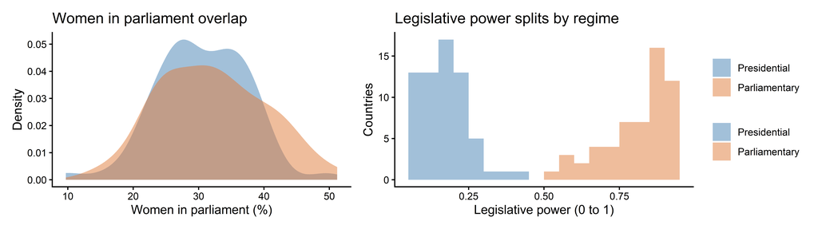

Figure 5: Left, women in parliament by regime type: the two groups cover a similar range, so both slopes can be learned from data. Right, the legislative power index by regime type: no country lies between the two groups, so statements about that middle range rest on the model, not on data.

```r
support_women <- ggplot(health, aes(x = women_parl, fill = regime)) +
  geom_density(alpha = 0.5, colour = NA) +
  scale_fill_manual(values = regime_cols) +
  theme_classic() +
  labs(
    x = "Women in parliament (%)",
    y = "Density",
    fill = NULL,
    title = "Women in parliament overlap"
  )
support_power <- ggplot(health, aes(x = leg_power, fill = regime)) +
  geom_histogram(binwidth = 0.05, boundary = 0, alpha = 0.5, colour = NA) +
  scale_fill_manual(values = regime_cols) +
  theme_classic() +
  labs(
    x = "Legislative power (0 to 1)",
    y = "Countries",
    fill = NULL,
    title = "Legislative power splits by regime"
  )
support_women + support_power + plot_layout(guides = "collect")
```

> **Q:** At which values of legislative power would you trust a statement about the slope of women in parliament least?

## Step 3: Formal model

**1. Outcome distribution.** Health spending is drawn from a normal distribution with mean $\mu_i$ and standard deviation $\sigma$:

$$y_i \sim \mathcal{N}(\mu_i, \sigma)
\tag{3}$$

**2. Linear predictor.** Equation 1, plus the control: the slope of women in parliament may differ by regime type, holding GDP constant.

$$\mu_i = \alpha + \beta_1 x_i + \beta_2 z_i + \beta_3 \, x_i z_i + \beta_4 c_i
\tag{4}$$

- $y_i$ is the health spending of country $i$, in percent of GDP.
- $x_i$ is its share of women in parliament **minus 30**, in percentage points.
- $z_i$ is 1 for a parliamentary and 0 for a presidential system, the **reference category**.
- $c_i$ is its GDP per capita **minus 18**, in thousand USD.

Both are **centred**, as in week 9: $x_i = c_i = 0$ is a typical country, not one with no women and no income.

Read $\sim$ as **is drawn from** (random) and $=$ as **is defined as** (fixed).

## Step 3: Two lines in one model

Set the dummy to 0 or 1 in Equation 4:

Table 4: The linear predictor of Equation 4 for each regime type, holding GDP constant.

| Regime | $z_i$ | Intercept | Slope of women in parliament |
| --- | --- | --- | --- |
| Presidential | 0 | $\alpha$ | $\beta_1$ |
| Parliamentary | 1 | $\alpha + \beta_2$ | $\beta_1 + \beta_3$ |

- $\beta_1$: the slope of women in parliament in **presidential** systems.
- $\beta_3$: how much **steeper** (or flatter) that slope is in **parliamentary** systems.
- $\beta_2$: the regime gap in spending **at 30 percent women** only, because $x_i = 0$ there.

**Warning**

**With an interaction, no single coefficient is “the” association of women in parliament with spending.** $\beta_1$ alone is the slope where the moderator is 0, here presidential systems.

## Step 3: The posterior

**3. Posterior, proportional form.**

$$P(\alpha, \beta_1, \beta_2, \beta_3, \beta_4, \sigma \mid \mathbf{y}, \mathbf{X}) \propto \mathcal{L}(\alpha, \beta_1, \beta_2, \beta_3, \beta_4, \sigma \mid \mathbf{y}, \mathbf{X}) \times P(\alpha) \, P(\beta_1) \, P(\beta_2) \, P(\beta_3) \, P(\beta_4) \, P(\sigma)
\tag{5}$$

- $\mathbf{y}$ is the health spending column, and $\mathbf{X}$ holds the predictor columns $\mathbf{x}$, $\mathbf{z}$ and $\mathbf{c}$, 120 rows each.
- The likelihood $\mathcal{L}$ comes from Equation 3 and Equation 4, applied to every country.

The left side lists every unknown: **six parameters, so six priors** to choose.

## Step 3: The complete model

$$\begin{aligned}
y_i &\sim \mathcal{N}(\mu_i, \sigma) && \text{outcome distribution} \\
\mu_i &= \alpha + \beta_1 x_i + \beta_2 z_i + \beta_3 \, x_i z_i + \beta_4 c_i && \text{linear predictor} \\
\alpha &\sim \mathcal{N}(7, 3) && \text{prior} \\
\beta_1, \beta_3, \beta_4 &\sim \mathcal{N}(0, 0.25) && \text{prior} \\
\beta_2 &\sim \mathcal{N}(0, 2) && \text{prior} \\
\sigma &\sim \text{Exponential}(0.5) && \text{prior}
\end{aligned}
\tag{6}$$

Every prior is argued on the scale of the outcome, percent of GDP:

**The intercept, $\alpha \sim \mathcal{N}(7, 3)$**

**Note**

**Expected spending of a presidential country with 30 percent women and a GDP of 18 thousand USD.** Public health spending typically lies between a few and a dozen percent of GDP. With 95 percent probability the prior lies between 1 and 13.

**The slopes, $\beta_1, \beta_3, \beta_4 \sim \mathcal{N}(0, 0.25)$**

**Note**

**Centred on no association, because the sign is what we want to learn.** 95 percent of the prior lies between $-0.5$ and $+0.5$ per percentage point of women in parliament (or per thousand USD). Ten points more women shifting spending by five points of GDP would already be enormous. $\beta_3$, the difference between two slopes, lives on the same scale, centred on **no moderation**.

**The regime gap, $\beta_2 \sim \mathcal{N}(0, 2)$**

**Note**

**Centred on no gap, open in both directions.** 95 percent of the prior lies between $-4$ and $+4$ points of GDP at 30 percent women.

**The residual standard deviation, $\sigma \sim \text{Exponential}(0.5)$**

**Note**

**Positive, and typically around 2.** An exponential with rate 0.5 has a mean of 2 points of GDP, so countries typically lie that far from their expected spending.

## Step 3: Four models to compare

Table 5: The four linear predictors fitted today. All share the outcome distribution of Equation 3 and the priors of Equation 6. The two interaction models differ only in what the moderator $z_i$ measures.

| Model | Linear predictor $\mu_i =$ | $z_i$ is | New idea |
| --- | --- | --- | --- |
| Bivariate | $\alpha + \beta_1 x_i$ |  | week 8 |
| Additive | $\alpha + \beta_1 x_i + \beta_2 z_i + \beta_4 c_i$ | parliamentary (0/1) | a control, week 9 |
| Interaction, dummy | $\alpha + \beta_1 x_i + \beta_2 z_i + \beta_3 \, x_i z_i + \beta_4 c_i$ | parliamentary (0/1) | the slope differs by regime |
| Interaction, continuous | $\alpha + \beta_1 x_i + \beta_2 z_i + \beta_3 \, x_i z_i + \beta_4 c_i$ | legislative power (0 to 1) | the slope changes with legislative power |

- **Legislative power** is an index from 0 (weakest) to 1 (strongest legislature).
- In the continuous model, the slope of women in parliament is $\beta_1 + \beta_3 z_i$: **a different slope for every value** of the index.

## Step 4: Prior predictive check

**View source**

```r
set.seed(2026)
tibble(
  draw = 1:50,
  alpha = rnorm(50, 7, 3),
  beta_1 = rnorm(50, 0, 0.25),
  beta_2 = rnorm(50, 0, 2),
  beta_3 = rnorm(50, 0, 0.25)
) |>
  expand_grid(women_parl = c(10, 50), parliamentary = c(0, 1)) |>
  mutate(
    women30 = women_parl - 30,
    mu = alpha + beta_1 * women30 + beta_2 * parliamentary +
      beta_3 * women30 * parliamentary,
    regime = if_else(parliamentary == 1, "Parliamentary", "Presidential")
  ) |>
  ggplot(aes(x = women_parl, y = mu, group = draw)) +
  geom_hline(yintercept = 0, linetype = "dashed", colour = "grey50") +
  geom_line(colour = col_3, alpha = 0.3) +
  facet_wrap(~ fct_relevel(regime, "Presidential")) +
  theme_classic() +
  labs(
    x = "Women in parliament (%)",
    y = "Expected health spending (% GDP)",
    title = "Average worlds our priors consider possible"
  )
```

[figure not shown]

Figure 6: Fifty lines per regime type drawn from the priors of the dummy interaction model, GDP held at 18 thousand USD. The priors allow rising and falling lines and different slopes in the two regime types. A few lines dip below zero spending at the extremes, so the priors are generous, but no line is absurd.

## Step 5: Fit the interaction model

```r
health <- health |>
  mutate(women30 = women_parl - 30, gdp18 = gdp_pc - 18) # centre

shared_priors <- c(
  prior(normal(7, 3), class = "b", coef = "Intercept"),
  prior(normal(0, 0.25), class = "b", coef = "women30"),
  prior(exponential(0.5), class = "sigma")
)

fit_dummy <- brm(
  health_spend ~ 0 + Intercept + women30 * parliamentary + gdp18,
  data = health,
  prior = c(
    shared_priors,
    prior(normal(0, 2), class = "b", coef = "parliamentary"),
    prior(normal(0, 0.25), class = "b", coef = "women30:parliamentary"),
    prior(normal(0, 0.25), class = "b", coef = "gdp18")
  ),
  seed = 2026,
  refresh = 0,
  file = here("website", "slides", "data", "week10-fit-dummy"),
  file_refit = "on_change"
)
```

## Step 5: Three models to compare

```r
fit_bivariate <- brm(
  health_spend ~ 0 + Intercept + women30,
  data = health, prior = shared_priors, seed = 2026, refresh = 0,
  file = here("website", "slides", "data", "week10-fit-bivariate"), file_refit = "on_change"
)

fit_additive <- brm(
  health_spend ~ 0 + Intercept + women30 + parliamentary + gdp18,
  data = health, seed = 2026, refresh = 0,
  prior = c(shared_priors, prior(normal(0, 2), class = "b", coef = "parliamentary"),
            prior(normal(0, 0.25), class = "b", coef = "gdp18")),
  file = here("website", "slides", "data", "week10-fit-additive"), file_refit = "on_change"
)

fit_continuous <- brm(
  health_spend ~ 0 + Intercept + women30 * leg_power + gdp18,
  data = health, seed = 2026, refresh = 0,
  prior = c(shared_priors, prior(normal(0, 2), class = "b", coef = "leg_power"),
            prior(normal(0, 0.25), class = "b", coef = "women30:leg_power"),
            prior(normal(0, 0.25), class = "b", coef = "gdp18")),
  file = here("website", "slides", "data", "week10-fit-continuous"), file_refit = "on_change"
)
```

## Step 6a: MCMC diagnostics

**View source**

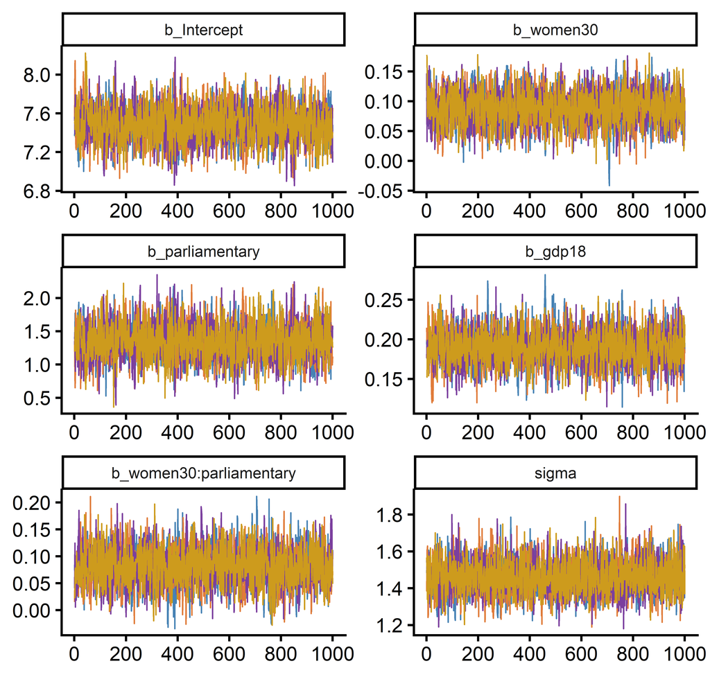

Figure 7: Trace plots for the dummy interaction model, four chains per parameter. The chains overlap and wander around the same region.

```r
mcmc_plot(fit_dummy, type = "trace", facet_args = list(ncol = 2)) +
  scale_colour_manual(values = chain_cols) +
  theme_classic() +
  theme(legend.position = "none", strip.text = element_text(size = 7))
```

```r
summary(fit_dummy)
```

```
 Family: gaussian
  Links: mu = identity
Formula: health_spend ~ 0 + Intercept + women30 * parliamentary + gdp18
   Data: health (Number of observations: 120)
  Draws: 4 chains, each with iter = 2000; warmup = 1000; thin = 1;
         total post-warmup draws = 4000

Regression Coefficients:
                      Estimate Est.Error l-95% CI u-95% CI Rhat Bulk_ESS
Intercept                 7.49      0.19     7.11     7.86 1.00     2635
women30                   0.09      0.03     0.03     0.15 1.00     2777
parliamentary             1.35      0.27     0.81     1.90 1.00     2826
gdp18                     0.19      0.02     0.15     0.23 1.00     3548
women30:parliamentary     0.08      0.04     0.01     0.15 1.00     2807
                      Tail_ESS
Intercept                 2572
women30                   2463
parliamentary             2610
gdp18                     2546
women30:parliamentary     2075

Further Distributional Parameters:
      Estimate Est.Error l-95% CI u-95% CI Rhat Bulk_ESS Tail_ESS
sigma     1.46      0.09     1.29     1.65 1.00     4170     2489

Draws were sampled using sample(hmc). For each parameter, Bulk_ESS
and Tail_ESS are effective sample size measures, and Rhat is the potential
scale reduction factor on split chains (at convergence, Rhat = 1).
```

Across all four models: largest R-hat 1.003, smallest ESS 2075, 0 divergent transitions, so **no evidence of non-convergence**.

## Step 6b: Posterior predictive check

**View source**

```r
set.seed(2026)
pp_check(fit_dummy, ndraws = 50) +
  theme_classic() +
  labs(x = "Health spending (% GDP)", title = "Data the model generates")
```

[figure not shown]

Figure 8: Posterior predictive check for the dummy interaction model. The dark line is the observed distribution of health spending, the pale lines are datasets generated by the fitted model. The generated data reproduce the location, spread and shape of the observed data.

> **Q:** Does the model generate data that look like ours?

# Step 7: Reporting

## One table, four models

The week 9 pipeline, written once as a function and applied to every model:

```r
tidy_model <- function(fit) {
  looic <- fit$criteria$loo$estimates["looic", ]
  tidy(fit, conf.level = 0.9) |>
    mutate(
      cell = sprintf("%.2f [%.2f, %.2f]", estimate, conf.low, conf.high)
    ) |>
    select(term, cell) |>
    add_row(
      term = "LOOIC",
      cell = sprintf("%.1f (SE %.1f)", looic["Estimate"], looic["SE"])
    )
}
```

- `cell` holds the posterior mean and the 90 percent credible interval as text.
- **LOOIC** $= -2 \times$ ELPD from week 9, so **lower is better**, with its standard error.

## Stack and spread

`bind_rows()` stacks the four tables, `pivot_wider()` gives each model its own column:

```r
tab_models <- list(
  Bivariate = fit_bivariate,
  Additive = fit_additive,
  Dummy = fit_dummy,
  Continuous = fit_continuous
) |>
  map(tidy_model) |>
  bind_rows(.id = "model") |>
  pivot_wider(names_from = model, values_from = cell) |>
  mutate(
    term = case_match(
      term,
      "(Intercept)" ~ "Intercept",
      "women30" ~ "Women in parliament (per point)",
      "parliamentary" ~ "Parliamentary",
      "leg_power" ~ "Legislative power",
      "women30:parliamentary" ~ "Women in parliament x parliamentary",
      "women30:leg_power" ~ "Women in parliament x legislative power",
      "gdp18" ~ "GDP (per thousand USD)",
      "sd__Observation" ~ "Residual SD",
      .default = term
    )
  ) |>
  arrange(term %in% c("Residual SD", "LOOIC"))
```

## Four models side by side

**View source**

```r
tab_models |>
  knitr::kable(
    col.names = c("", "Bivariate", "Additive", "Dummy", "Continuous")
  )
```

Table 6: Posterior means and 90 percent credible intervals from four models of health spending (percent of GDP), 120 countries. The intercept is a country with 30 percent women, a GDP of 18 thousand USD and, where included, a presidential system or a legislative power of 0. Dummy and Continuous are the two interaction models. LOOIC is lower for models that predict new countries better.

|  | Bivariate | Additive | Dummy | Continuous |
| --- | --- | --- | --- | --- |
| Intercept | 7.86 [7.56, 8.17] | 7.47 [7.18, 7.78] | 7.49 [7.18, 7.79] | 7.09 [6.73, 7.46] |
| Women in parliament (per point) | 0.24 [0.20, 0.28] | 0.13 [0.10, 0.17] | 0.09 [0.04, 0.14] | 0.05 [-0.00, 0.10] |
| Parliamentary |  | 1.43 [0.99, 1.88] | 1.35 [0.90, 1.80] |  |
| GDP (per thousand USD) |  | 0.19 [0.16, 0.23] | 0.19 [0.15, 0.23] | 0.18 [0.15, 0.22] |
| Women in parliament x parliamentary |  |  | 0.08 [0.02, 0.14] |  |
| Legislative power |  |  |  | 2.12 [1.47, 2.76] |
| Women in parliament x legislative power |  |  |  | 0.16 [0.08, 0.24] |
| Residual SD | 2.02 [1.82, 2.24] | 1.49 [1.33, 1.65] | 1.46 [1.31, 1.62] | 1.40 [1.26, 1.56] |
| LOOIC | 511.5 (SE 16.0) | 440.7 (SE 15.3) | 437.5 (SE 15.6) | 426.6 (SE 13.8) |

## Comparing models with `loo_compare()`

`loo_compare()` orders the models by ELPD, best first, and gives each difference with its **standard error**:

```r
loo_compare(fit_bivariate, fit_additive, fit_dummy, fit_continuous)
```

```
          model elpd_diff se_diff p_worse diag_diff diag_elpd
 fit_continuous       0.0     0.0      NA
      fit_dummy      -5.5     2.7    0.98
   fit_additive      -7.0     3.3    0.98
  fit_bivariate     -42.5     7.6    1.00
```

**Important**

**LOO ranks how well models predict, not whether the moderator is the right one.** The choice of moderator comes from theory, at step 1.

## Expected and predicted spending

**View source**

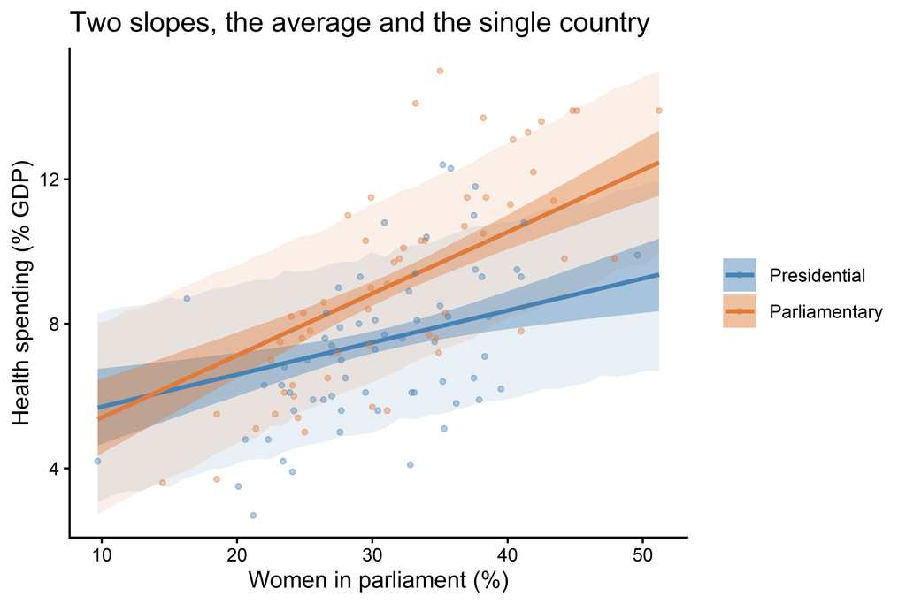

Figure 9: Expected health spending (line and narrow band) and predicted spending (wide band), both 90 percent intervals, from the dummy interaction model with GDP held at 18 thousand USD. The lines are no longer parallel: spending rises faster with women in parliament in parliamentary systems.

```r
ggplot(bands, aes(x = women_parl, fill = regime, colour = regime)) +
  geom_ribbon(aes(ymin = pr_lo, ymax = pr_hi), alpha = 0.12, colour = NA) +
  geom_ribbon(aes(ymin = ep_lo, ymax = ep_hi), alpha = 0.4, colour = NA) +
  geom_line(aes(y = mid), linewidth = 1) +
  geom_point(
    data = health,
    aes(x = women_parl, y = health_spend, colour = regime),
    inherit.aes = FALSE,
    alpha = 0.4,
    size = 1
  ) +
  scale_colour_manual(values = regime_cols) +
  scale_fill_manual(values = regime_cols) +
  theme_classic() +
  labs(
    x = "Women in parliament (%)",
    y = "Health spending (% GDP)",
    colour = NULL,
    fill = NULL,
    title = "Two slopes, the average and the single country"
  )
```

**Slope of women in parliament**, per percentage point:

- presidential: **0.09**, 90 percent interval [0.04, 0.14]
- parliamentary: **0.17**, from 0.13 to 0.21

**99 percent** of the posterior says the parliamentary slope is steeper.

**Predicted value**: one new parliamentary country with 40 percent women spends between **8.1 and 13** percent of GDP (90 percent).

## The marginal effect, as a function of the moderator

**View source**

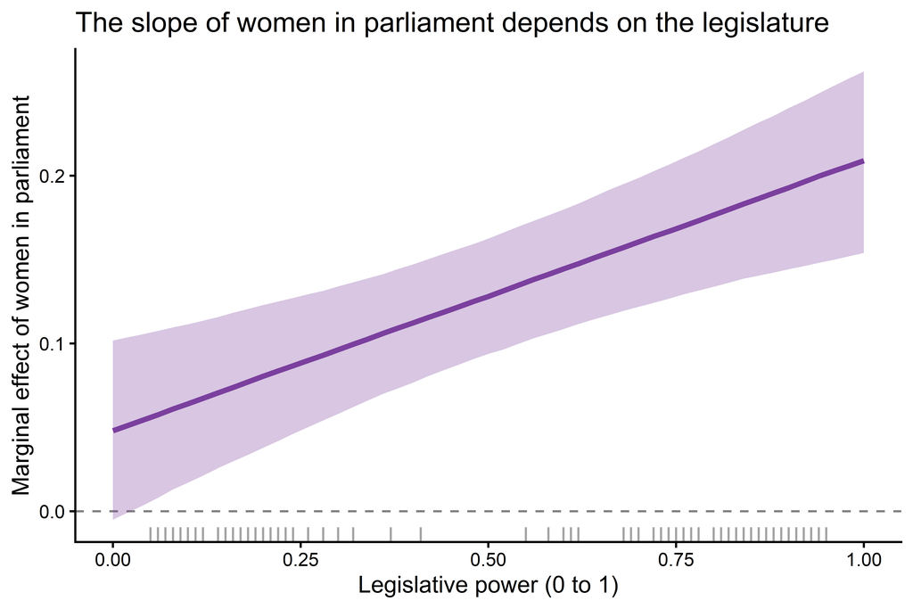

Figure 10: The marginal effect of women in parliament on expected health spending (percentage points of GDP per point of women) as a function of legislative power, from the continuous interaction model: posterior median and 90 percent credible interval. Ticks at the bottom mark observed countries. The slope grows with legislative power.

```r
ggplot(me_bands, aes(x = leg_power)) +
  geom_hline(yintercept = 0, linetype = "dashed", colour = "grey50") +
  geom_ribbon(aes(ymin = lo, ymax = hi), fill = col_3, alpha = 0.3) +
  geom_line(aes(y = mid), colour = col_3, linewidth = 1.2) +
  geom_rug(data = health, aes(x = leg_power), colour = "grey40", alpha = 0.6) +
  theme_classic() +
  labs(
    x = "Legislative power (0 to 1)",
    y = "Marginal effect of women in parliament",
    title = "The slope of women in parliament depends on the legislature"
  )
```

For every posterior draw $s$, at every value $z$:

$$\text{slope}^{(s)}(z) = \beta_1^{(s)} + \beta_3^{(s)} z
\tag{7}$$

- weak legislature, $z = 0.1$: **0.06** [0.02, 0.11]
- strong legislature, $z = 0.9$: **0.19** [0.14, 0.24]

No country lies between 0.41 and 0.55, so that stretch of the line is the model’s, not the data’s.

## Step 8: Limitations

- **Synthetic data:** built so the interaction is easy to see.
- **Linearity of moderation:** the continuous model assumes the slope changes by the **same** amount for every step in legislative power (Brambor et al. 2006). A binary moderator cannot violate this, a continuous one can.
- **Common support:** no country has middling legislative power, so the marginal effect there is interpolated.
- **A dummy throws information away:** it treats every parliamentary system as equally strong.
- **Association, not cause:** countries with more women in parliament may differ in ways the model does not include.

**Note**

**An interaction is a claim about the world, like a control.** It belongs in the model because a theory predicts it, at step 1, not because it improves the LOOIC.

# Wrap-up

## Learning goals: achieved?

Table 7: The week 10 learning goals, each with its key answer and the part of the session that covers it.

| # | Learning goal | Key answer | Where |
| --- | --- | --- | --- |
| 1 | What an interaction does | A product term makes the slope of $x$ equal $\beta_1 + \beta_3 z$, so it depends on the moderator | Interactions |
| 2 | Categories as dummies | $k$ categories become $k - 1$ dummies, each a difference from the reference category | Dummies |
| 3 | Fit and read an interaction model | $\beta_1$ is the slope where $z = 0$, $\beta_1 + \beta_3$ where $z = 1$ | Two lines |
| 4 | Compare models | One table with LOOIC, then `loo_compare()` for the differences and their uncertainty | Reporting |
| 5 | Show it in a figure | Non-parallel expected and predicted values, and the marginal effect against the moderator | Marginal effect |

## Homework and outlook

- `hw-10`: the whole workflow with an interaction term, due 2 December. Linked from the Schedule.
- A sample solution is published after the due date.

**Important**

**Individual feedback is only available through the opt-in path.** To opt in, add an open-source `license.md` to your submission repo **and** mark your finished homework with a commit whose message is `final submission`.

**Next week:** outcomes that are yes or no, such as a vote to leave the EU. The linear predictor stays, and one link line is added to the model card: **logit and probit**.

## References

Brambor, Thomas, William Roberts Clark, and Matt Golder. 2006. “Understanding Interaction Models: Improving Empirical Analyses.” *Political Analysis* 14 (1): 63–82. https://doi.org/10.1093/pan/mpi014.

# Appendix

## Caching model fits in Quarto

Every render re-runs every chunk, including slow `brm()` calls. Two ways around it:

**Cache chunks** in the YAML header, or per chunk with `#| cache: true`:

```yaml
execute:
  cache: true
```

Quarto stores results in a `_cache/` folder and reruns a chunk only when its code changes.

**Save the fit to a file** with `brm()` itself, as in step 5:

```r
fit <- brm(
  ...,
  file = here("fits", "fit-dummy"),
  file_refit = "on_change"
)
```

The model is refitted only when its formula, data or priors change.

**Warning**

**Add `_cache/` to your `.gitignore`.** Cache folders are large and machine-specific, so they do not belong in your repository.